> **Tip**: Welcome to the Investigate a Dataset project! You will find tips in quoted sections like this to help organize your approach to your investigation. Before submitting your project, it will be a good idea to go back through your report and remove these sections to make the presentation of your work as tidy as possible. First things first, you might want to double-click this Markdown cell and change the title so that it reflects your dataset and investigation.

# Project: Investigate movies data from TMDB

- Introduction
- Data Wrangling
- Exploratory Data Analysis
- Conclusions

## Introduction

> In this Notebook, I will try to explore movies data from TMDB tbat consist of 10000 movies collection on it. I will focus explore data in this dataset to get information about Which genres are popular by the time past. Furthermore, I will configure what features which correlate with high revenues movies.

```python
#import libraries

import pandas as pd
import numpy as np
import matplotlib.pyplot as plt
% matplotlib inline

# load dataset
df = pd.read_csv('tmdb-movies.csv')
df.head(20)
```

|  | id | imdb_id | popularity | budget | revenue | original_title | cast | homepage | director | tagline | ... | overview | runtime | genres | production_companies | release_date | vote_count | vote_average | release_year | budget_adj | revenue_adj |
| --- | --- | --- | --- | --- | --- | --- | --- | --- | --- | --- | --- | --- | --- | --- | --- | --- | --- | --- | --- | --- | --- |
| 0 | 135397 | tt0369610 | 32.985763 | 150000000 | 1513528810 | Jurassic World | Chris Pratt\|Bryce Dallas Howard\|Irrfan Khan\|Vi... | http://www.jurassicworld.com/ | Colin Trevorrow | The park is open. | ... | Twenty-two years after the events of Jurassic ... | 124 | Action\|Adventure\|Science Fiction\|Thriller | Universal Studios\|Amblin Entertainment\|Legenda... | 6/9/15 | 5562 | 6.5 | 2015 | 1.379999e+08 | 1.392446e+09 |
| 1 | 76341 | tt1392190 | 28.419936 | 150000000 | 378436354 | Mad Max: Fury Road | Tom Hardy\|Charlize Theron\|Hugh Keays-Byrne\|Nic... | http://www.madmaxmovie.com/ | George Miller | What a Lovely Day. | ... | An apocalyptic story set in the furthest reach... | 120 | Action\|Adventure\|Science Fiction\|Thriller | Village Roadshow Pictures\|Kennedy Miller Produ... | 5/13/15 | 6185 | 7.1 | 2015 | 1.379999e+08 | 3.481613e+08 |
| 2 | 262500 | tt2908446 | 13.112507 | 110000000 | 295238201 | Insurgent | Shailene Woodley\|Theo James\|Kate Winslet\|Ansel... | http://www.thedivergentseries.movie/#insurgent | Robert Schwentke | One Choice Can Destroy You | ... | Beatrice Prior must confront her inner demons ... | 119 | Adventure\|Science Fiction\|Thriller | Summit Entertainment\|Mandeville Films\|Red Wago... | 3/18/15 | 2480 | 6.3 | 2015 | 1.012000e+08 | 2.716190e+08 |
| 3 | 140607 | tt2488496 | 11.173104 | 200000000 | 2068178225 | Star Wars: The Force Awakens | Harrison Ford\|Mark Hamill\|Carrie Fisher\|Adam D... | http://www.starwars.com/films/star-wars-episod... | J.J. Abrams | Every generation has a story. | ... | Thirty years after defeating the Galactic Empi... | 136 | Action\|Adventure\|Science Fiction\|Fantasy | Lucasfilm\|Truenorth Productions\|Bad Robot | 12/15/15 | 5292 | 7.5 | 2015 | 1.839999e+08 | 1.902723e+09 |
| 4 | 168259 | tt2820852 | 9.335014 | 190000000 | 1506249360 | Furious 7 | Vin Diesel\|Paul Walker\|Jason Statham\|Michelle ... | http://www.furious7.com/ | James Wan | Vengeance Hits Home | ... | Deckard Shaw seeks revenge against Dominic Tor... | 137 | Action\|Crime\|Thriller | Universal Pictures\|Original Film\|Media Rights ... | 4/1/15 | 2947 | 7.3 | 2015 | 1.747999e+08 | 1.385749e+09 |
| 5 | 281957 | tt1663202 | 9.110700 | 135000000 | 532950503 | The Revenant | Leonardo DiCaprio\|Tom Hardy\|Will Poulter\|Domhn... | http://www.foxmovies.com/movies/the-revenant | Alejandro González Iñárritu | (n. One who has returned, as if from the dead.) | ... | In the 1820s, a frontiersman, Hugh Glass, sets... | 156 | Western\|Drama\|Adventure\|Thriller | Regency Enterprises\|Appian Way\|CatchPlay\|Anony... | 12/25/15 | 3929 | 7.2 | 2015 | 1.241999e+08 | 4.903142e+08 |
| 6 | 87101 | tt1340138 | 8.654359 | 155000000 | 440603537 | Terminator Genisys | Arnold Schwarzenegger\|Jason Clarke\|Emilia Clar... | http://www.terminatormovie.com/ | Alan Taylor | Reset the future | ... | The year is 2029. John Connor, leader of the r... | 125 | Science Fiction\|Action\|Thriller\|Adventure | Paramount Pictures\|Skydance Productions | 6/23/15 | 2598 | 5.8 | 2015 | 1.425999e+08 | 4.053551e+08 |
| 7 | 286217 | tt3659388 | 7.667400 | 108000000 | 595380321 | The Martian | Matt Damon\|Jessica Chastain\|Kristen Wiig\|Jeff ... | http://www.foxmovies.com/movies/the-martian | Ridley Scott | Bring Him Home | ... | During a manned mission to Mars, Astronaut Mar... | 141 | Drama\|Adventure\|Science Fiction | Twentieth Century Fox Film Corporation\|Scott F... | 9/30/15 | 4572 | 7.6 | 2015 | 9.935996e+07 | 5.477497e+08 |
| 8 | 211672 | tt2293640 | 7.404165 | 74000000 | 1156730962 | Minions | Sandra Bullock\|Jon Hamm\|Michael Keaton\|Allison... | http://www.minionsmovie.com/ | Kyle Balda\|Pierre Coffin | Before Gru, they had a history of bad bosses | ... | Minions Stuart, Kevin and Bob are recruited by... | 91 | Family\|Animation\|Adventure\|Comedy | Universal Pictures\|Illumination Entertainment | 6/17/15 | 2893 | 6.5 | 2015 | 6.807997e+07 | 1.064192e+09 |
| 9 | 150540 | tt2096673 | 6.326804 | 175000000 | 853708609 | Inside Out | Amy Poehler\|Phyllis Smith\|Richard Kind\|Bill Ha... | http://movies.disney.com/inside-out | Pete Docter | Meet the little voices inside your head. | ... | Growing up can be a bumpy road, and it's no ex... | 94 | Comedy\|Animation\|Family | Walt Disney Pictures\|Pixar Animation Studios\|W... | 6/9/15 | 3935 | 8.0 | 2015 | 1.609999e+08 | 7.854116e+08 |
| 10 | 206647 | tt2379713 | 6.200282 | 245000000 | 880674609 | Spectre | Daniel Craig\|Christoph Waltz\|Léa Seydoux\|Ralp... | http://www.sonypictures.com/movies/spectre/ | Sam Mendes | A Plan No One Escapes | ... | A cryptic message from Bond’s past sends him... | 148 | Action\|Adventure\|Crime | Columbia Pictures\|Danjaq\|B24 | 10/26/15 | 3254 | 6.2 | 2015 | 2.253999e+08 | 8.102203e+08 |
| 11 | 76757 | tt1617661 | 6.189369 | 176000003 | 183987723 | Jupiter Ascending | Mila Kunis\|Channing Tatum\|Sean Bean\|Eddie Redm... | http://www.jupiterascending.com | Lana Wachowski\|Lilly Wachowski | Expand your universe. | ... | In a universe where human genetic material is ... | 124 | Science Fiction\|Fantasy\|Action\|Adventure | Village Roadshow Pictures\|Dune Entertainment\|A... | 2/4/15 | 1937 | 5.2 | 2015 | 1.619199e+08 | 1.692686e+08 |
| 12 | 264660 | tt0470752 | 6.118847 | 15000000 | 36869414 | Ex Machina | Domhnall Gleeson\|Alicia Vikander\|Oscar Isaac\|S... | http://exmachina-movie.com/ | Alex Garland | There is nothing more human than the will to s... | ... | Caleb, a 26 year old coder at the world's larg... | 108 | Drama\|Science Fiction | DNA Films\|Universal Pictures International (UP... | 1/21/15 | 2854 | 7.6 | 2015 | 1.379999e+07 | 3.391985e+07 |
| 13 | 257344 | tt2120120 | 5.984995 | 88000000 | 243637091 | Pixels | Adam Sandler\|Michelle Monaghan\|Peter Dinklage\|... | http://www.pixels-movie.com/ | Chris Columbus | Game On. | ... | Video game experts are recruited by the milita... | 105 | Action\|Comedy\|Science Fiction | Columbia Pictures\|Happy Madison Productions | 7/16/15 | 1575 | 5.8 | 2015 | 8.095996e+07 | 2.241460e+08 |
| 14 | 99861 | tt2395427 | 5.944927 | 280000000 | 1405035767 | Avengers: Age of Ultron | Robert Downey Jr.\|Chris Hemsworth\|Mark Ruffalo... | http://marvel.com/movies/movie/193/avengers_ag... | Joss Whedon | A New Age Has Come. | ... | When Tony Stark tries to jumpstart a dormant p... | 141 | Action\|Adventure\|Science Fiction | Marvel Studios\|Prime Focus\|Revolution Sun Studios | 4/22/15 | 4304 | 7.4 | 2015 | 2.575999e+08 | 1.292632e+09 |
| 15 | 273248 | tt3460252 | 5.898400 | 44000000 | 155760117 | The Hateful Eight | Samuel L. Jackson\|Kurt Russell\|Jennifer Jason ... | http://thehatefuleight.com/ | Quentin Tarantino | No one comes up here without a damn good reason. | ... | Bounty hunters seek shelter from a raging bliz... | 167 | Crime\|Drama\|Mystery\|Western | Double Feature Films\|The Weinstein Company\|Fil... | 12/25/15 | 2389 | 7.4 | 2015 | 4.047998e+07 | 1.432992e+08 |
| 16 | 260346 | tt2446042 | 5.749758 | 48000000 | 325771424 | Taken 3 | Liam Neeson\|Forest Whitaker\|Maggie Grace\|Famke... | http://www.taken3movie.com/ | Olivier Megaton | It Ends Here | ... | Ex-government operative Bryan Mills finds his ... | 109 | Crime\|Action\|Thriller | Twentieth Century Fox Film Corporation\|M6 Film... | 1/1/15 | 1578 | 6.1 | 2015 | 4.415998e+07 | 2.997096e+08 |
| 17 | 102899 | tt0478970 | 5.573184 | 130000000 | 518602163 | Ant-Man | Paul Rudd\|Michael Douglas\|Evangeline Lilly\|Cor... | http://marvel.com/movies/movie/180/ant-man | Peyton Reed | Heroes Don't Get Any Bigger | ... | Armed with the astonishing ability to shrink i... | 115 | Science Fiction\|Action\|Adventure | Marvel Studios | 7/14/15 | 3779 | 7.0 | 2015 | 1.195999e+08 | 4.771138e+08 |
| 18 | 150689 | tt1661199 | 5.556818 | 95000000 | 542351353 | Cinderella | Lily James\|Cate Blanchett\|Richard Madden\|Helen... | NaN | Kenneth Branagh | Midnight is just the beginning. | ... | When her father unexpectedly passes away, youn... | 112 | Romance\|Fantasy\|Family\|Drama | Walt Disney Pictures\|Genre Films\|Beagle Pug Fi... | 3/12/15 | 1495 | 6.8 | 2015 | 8.739996e+07 | 4.989630e+08 |
| 19 | 131634 | tt1951266 | 5.476958 | 160000000 | 650523427 | The Hunger Games: Mockingjay - Part 2 | Jennifer Lawrence\|Josh Hutcherson\|Liam Hemswor... | http://www.thehungergames.movie/ | Francis Lawrence | The fire will burn forever. | ... | With the nation of Panem in a full scale war, ... | 136 | War\|Adventure\|Science Fiction | Studio Babelsberg\|StudioCanal\|Lionsgate\|Walt D... | 11/18/15 | 2380 | 6.5 | 2015 | 1.471999e+08 | 5.984813e+08 |

20 rows × 21 columns

## Data Wrangling

> **Tip**: In this section of the report, you will load in the data, check for cleanliness, and then trim and clean your dataset for analysis. Make sure that you document your steps carefully and justify your cleaning decisions.

### General Properties

```python
# info about data
df.info()
```

```
<class 'pandas.core.frame.DataFrame'>
RangeIndex: 10866 entries, 0 to 10865
Data columns (total 21 columns):
id                      10866 non-null int64
imdb_id                 10856 non-null object
popularity              10866 non-null float64
budget                  10866 non-null int64
revenue                 10866 non-null int64
original_title          10866 non-null object
cast                    10790 non-null object
homepage                2936 non-null object
director                10822 non-null object
tagline                 8042 non-null object
keywords                9373 non-null object
overview                10862 non-null object
runtime                 10866 non-null int64
genres                  10843 non-null object
production_companies    9836 non-null object
release_date            10866 non-null object
vote_count              10866 non-null int64
vote_average            10866 non-null float64
release_year            10866 non-null int64
budget_adj              10866 non-null float64
revenue_adj             10866 non-null float64
dtypes: float64(4), int64(6), object(11)
memory usage: 1.7+ MB
```

```python
df.shape
```

```
(10866, 21)
```

```python
df.nunique()
```

```
id                      10865
imdb_id                 10855
popularity              10814
budget                    557
revenue                  4702
original_title          10571
cast                    10719
homepage                 2896
director                 5067
tagline                  7997
keywords                 8804
overview                10847
runtime                   247
genres                   2039
production_companies     7445
release_date             5909
vote_count               1289
vote_average               72
release_year               56
budget_adj               2614
revenue_adj              4840
dtype: int64
```

```python
df.describe()
```

|  | id | popularity | budget | revenue | runtime | vote_count | vote_average | release_year | budget_adj | revenue_adj |
| --- | --- | --- | --- | --- | --- | --- | --- | --- | --- | --- |
| count | 10866.000000 | 10866.000000 | 1.086600e+04 | 1.086600e+04 | 10866.000000 | 10866.000000 | 10866.000000 | 10866.000000 | 1.086600e+04 | 1.086600e+04 |
| mean | 66064.177434 | 0.646441 | 1.462570e+07 | 3.982332e+07 | 102.070863 | 217.389748 | 5.974922 | 2001.322658 | 1.755104e+07 | 5.136436e+07 |
| std | 92130.136561 | 1.000185 | 3.091321e+07 | 1.170035e+08 | 31.381405 | 575.619058 | 0.935142 | 12.812941 | 3.430616e+07 | 1.446325e+08 |
| min | 5.000000 | 0.000065 | 0.000000e+00 | 0.000000e+00 | 0.000000 | 10.000000 | 1.500000 | 1960.000000 | 0.000000e+00 | 0.000000e+00 |
| 25% | 10596.250000 | 0.207583 | 0.000000e+00 | 0.000000e+00 | 90.000000 | 17.000000 | 5.400000 | 1995.000000 | 0.000000e+00 | 0.000000e+00 |
| 50% | 20669.000000 | 0.383856 | 0.000000e+00 | 0.000000e+00 | 99.000000 | 38.000000 | 6.000000 | 2006.000000 | 0.000000e+00 | 0.000000e+00 |
| 75% | 75610.000000 | 0.713817 | 1.500000e+07 | 2.400000e+07 | 111.000000 | 145.750000 | 6.600000 | 2011.000000 | 2.085325e+07 | 3.369710e+07 |
| max | 417859.000000 | 32.985763 | 4.250000e+08 | 2.781506e+09 | 900.000000 | 9767.000000 | 9.200000 | 2015.000000 | 4.250000e+08 | 2.827124e+09 |

> **Tip**: You should *not* perform too many operations in each cell. Create cells freely to explore your data. One option that you can take with this project is to do a lot of explorations in an initial notebook. These don't have to be organized, but make sure you use enough comments to understand the purpose of each code cell. Then, after you're done with your analysis, create a duplicate notebook where you will trim the excess and organize your steps so that you have a flowing, cohesive report.

> **Tip**: Make sure that you keep your reader informed on the steps that you are taking in your investigation. Follow every code cell, or every set of related code cells, with a markdown cell to describe to the reader what was found in the preceding cell(s). Try to make it so that the reader can then understand what they will be seeing in the following cell(s).

### Data Cleaning

```python
# After discussing the structure of the data and any problems that need to be
#   cleaned, perform those cleaning steps in the second part of this section.

#listing dropped columns
drop_col = ['id', 'imdb_id', 'original_title', 'cast', 'homepage', 'tagline', 'keywords', 'production_companies','overview']

#drop listed column
df.drop(drop_col, axis=1, inplace=True)
```

```python
# check if there is duplication on data
df.duplicated().sum()
```

```
1
```

```python
#delete duplicate data

df.drop(df.index[df.duplicated()][0], axis=0, inplace=True)
```

```python
df.head(10)
```

|  | popularity | budget | revenue | director | runtime | genres | release_date | vote_count | vote_average | release_year | budget_adj | revenue_adj |
| --- | --- | --- | --- | --- | --- | --- | --- | --- | --- | --- | --- | --- |
| 0 | 32.985763 | 150000000 | 1513528810 | Colin Trevorrow | 124 | Action\|Adventure\|Science Fiction\|Thriller | 6/9/15 | 5562 | 6.5 | 2015 | 1.379999e+08 | 1.392446e+09 |
| 1 | 28.419936 | 150000000 | 378436354 | George Miller | 120 | Action\|Adventure\|Science Fiction\|Thriller | 5/13/15 | 6185 | 7.1 | 2015 | 1.379999e+08 | 3.481613e+08 |
| 2 | 13.112507 | 110000000 | 295238201 | Robert Schwentke | 119 | Adventure\|Science Fiction\|Thriller | 3/18/15 | 2480 | 6.3 | 2015 | 1.012000e+08 | 2.716190e+08 |
| 3 | 11.173104 | 200000000 | 2068178225 | J.J. Abrams | 136 | Action\|Adventure\|Science Fiction\|Fantasy | 12/15/15 | 5292 | 7.5 | 2015 | 1.839999e+08 | 1.902723e+09 |
| 4 | 9.335014 | 190000000 | 1506249360 | James Wan | 137 | Action\|Crime\|Thriller | 4/1/15 | 2947 | 7.3 | 2015 | 1.747999e+08 | 1.385749e+09 |
| 5 | 9.110700 | 135000000 | 532950503 | Alejandro González Iñárritu | 156 | Western\|Drama\|Adventure\|Thriller | 12/25/15 | 3929 | 7.2 | 2015 | 1.241999e+08 | 4.903142e+08 |
| 6 | 8.654359 | 155000000 | 440603537 | Alan Taylor | 125 | Science Fiction\|Action\|Thriller\|Adventure | 6/23/15 | 2598 | 5.8 | 2015 | 1.425999e+08 | 4.053551e+08 |
| 7 | 7.667400 | 108000000 | 595380321 | Ridley Scott | 141 | Drama\|Adventure\|Science Fiction | 9/30/15 | 4572 | 7.6 | 2015 | 9.935996e+07 | 5.477497e+08 |
| 8 | 7.404165 | 74000000 | 1156730962 | Kyle Balda\|Pierre Coffin | 91 | Family\|Animation\|Adventure\|Comedy | 6/17/15 | 2893 | 6.5 | 2015 | 6.807997e+07 | 1.064192e+09 |
| 9 | 6.326804 | 175000000 | 853708609 | Pete Docter | 94 | Comedy\|Animation\|Family | 6/9/15 | 3935 | 8.0 | 2015 | 1.609999e+08 | 7.854116e+08 |

```python
# recheck the duplication still exist or not
df.duplicated().sum()
```

```
0
```

Result from duplication checking is 0, which means there are no duplication data anymore in the dataframe.

```python
# rechecking data info after selecting features and duplication cleaning

df.info()
```

```
<class 'pandas.core.frame.DataFrame'>
Int64Index: 10865 entries, 0 to 10865
Data columns (total 12 columns):
popularity      10865 non-null float64
budget          10865 non-null int64
revenue         10865 non-null int64
director        10821 non-null object
runtime         10865 non-null int64
genres          10842 non-null object
release_date    10865 non-null object
vote_count      10865 non-null int64
vote_average    10865 non-null float64
release_year    10865 non-null int64
budget_adj      10865 non-null float64
revenue_adj     10865 non-null float64
dtypes: float64(4), int64(5), object(3)
memory usage: 1.1+ MB
```

After filtered, there are still null value in genres and directors. It needs to be cleaned, since the data numbers is small.

```python
#getting list of null row
list_na=list(df.index[df.isnull().any(axis=1)])
#print(list_na)

#drop null row from dataframe
df.drop(list_na, axis=0, inplace=True)
df.info()
```

```
<class 'pandas.core.frame.DataFrame'>
Int64Index: 10800 entries, 0 to 10865
Data columns (total 12 columns):
popularity      10800 non-null float64
budget          10800 non-null int64
revenue         10800 non-null int64
director        10800 non-null object
runtime         10800 non-null int64
genres          10800 non-null object
release_date    10800 non-null object
vote_count      10800 non-null int64
vote_average    10800 non-null float64
release_year    10800 non-null int64
budget_adj      10800 non-null float64
revenue_adj     10800 non-null float64
dtypes: float64(4), int64(5), object(3)
memory usage: 1.1+ MB
```

## separating features which contains many data in one column

This process is needed to make data exploration easire. Genres column has multiple data on it, so it need to be separated using string extraction and make it into seceral data.

```python
# splitting data in genres

#add count symbol column for tagging
df['count_symbol'] = df['genres'].apply(lambda x:str.count(x,'|'))
```

```python
# divide table by count symbol
df1 = df[df['count_symbol']==0]
df2 = df[df['count_symbol']==1]
df3 = df[df['count_symbol']==2]
df4 = df[df['count_symbol']==3]
df5 = df[df['count_symbol']==4]

df5.head()
```

|  | popularity | budget | revenue | director | runtime | genres | release_date | vote_count | vote_average | release_year | budget_adj | revenue_adj | count_symbol |
| --- | --- | --- | --- | --- | --- | --- | --- | --- | --- | --- | --- | --- | --- |
| 20 | 5.462138 | 190000000 | 209035668 | Brad Bird | 130 | Action\|Family\|Science Fiction\|Adventure\|Mystery | 5/19/15 | 1899 | 6.2 | 2015 | 1.747999e+08 | 1.923127e+08 | 4 |
| 37 | 3.339135 | 175000000 | 331926147 | Peter Sohn | 93 | Adventure\|Animation\|Comedy\|Family\|Fantasy | 11/14/15 | 1087 | 6.6 | 2015 | 1.609999e+08 | 3.053719e+08 | 4 |
| 38 | 3.237370 | 50000000 | 71561644 | Jaume Collet-Serra | 114 | Action\|Crime\|Drama\|Mystery\|Thriller | 3/11/15 | 814 | 6.3 | 2015 | 4.599998e+07 | 6.583668e+07 | 4 |
| 46 | 2.976436 | 135000000 | 368871007 | Tim Johnson | 94 | Fantasy\|Comedy\|Animation\|Science Fiction\|Family | 3/18/15 | 1060 | 6.9 | 2015 | 1.241999e+08 | 3.393612e+08 | 4 |
| 49 | 2.885126 | 4000000 | 9064511 | Yorgos Lanthimos | 118 | Thriller\|Comedy\|Drama\|Romance\|Science Fiction | 10/8/15 | 638 | 6.6 | 2015 | 3.679998e+06 | 8.339346e+06 | 4 |

```python
#split data which having count_symbol == 1
df2a = df2.copy()
df2b = df2.copy()

#dplit genres
df2a['genres'] = df2a['genres'].apply(lambda x: x.split("|")[0])
df2b['genres'] = df2b['genres'].apply(lambda x: x.split("|")[1])

print(df2a.shape)

df2_concat = df2a.append(df2b)
```

```
(3427, 13)
```

```python
#split data which having count_symbol == 2
df3a = df3.copy()
df3b = df3.copy()
df3c = df3.copy()

#dplit genres
df3a['genres'] = df3a['genres'].apply(lambda x: x.split("|")[0])
df3b['genres'] = df3b['genres'].apply(lambda x: x.split("|")[1])
df3c['genres'] = df3c['genres'].apply(lambda x: x.split("|")[2])

print(df3a.shape)

df3_concat = df3a.append(df3b)
df3_concat = df3_concat.append(df3c)
```

```
(3088, 13)
```

```python
#split data which having count_symbol == 2
df4a = df4.copy()
df4b = df4.copy()
df4c = df4.copy()
df4d = df4.copy()

#dplit genres
df4a['genres'] = df4a['genres'].apply(lambda x: x.split("|")[0])
df4b['genres'] = df4b['genres'].apply(lambda x: x.split("|")[1])
df4c['genres'] = df4c['genres'].apply(lambda x: x.split("|")[2])
df4d['genres'] = df4d['genres'].apply(lambda x: x.split("|")[3])

print(df4a.shape)

df4_concat = df4a.append(df4b)
df4_concat = df4_concat.append(df4c)
df4_concat = df4_concat.append(df4d)
```

```
(1435, 13)
```

```python
#split data which having count_symbol == 2
df5a = df5.copy()
df5b = df5.copy()
df5c = df5.copy()
df5d = df5.copy()
df5e = df5.copy()

#dplit genres
df5a['genres'] = df5a['genres'].apply(lambda x: x.split("|")[0])
df5b['genres'] = df5b['genres'].apply(lambda x: x.split("|")[1])
df5c['genres'] = df5c['genres'].apply(lambda x: x.split("|")[2])
df5d['genres'] = df5d['genres'].apply(lambda x: x.split("|")[3])
df5e['genres'] = df5e['genres'].apply(lambda x: x.split("|")[4])

print(df5a.shape)

df5_concat = df5a.append(df5b)
df5_concat = df5_concat.append(df5c)
df5_concat = df5_concat.append(df5d)
df5_concat = df5_concat.append(df5e)
```

```
(539, 13)
```

```python
# append all data into one dataframe

df_sep_gen = df1.append(df2_concat)
df_sep_gen = df_sep_gen.append(df3_concat)
df_sep_gen = df_sep_gen.append(df4_concat)
df_sep_gen = df_sep_gen.append(df5_concat)

df_sep_gen.shape
```

```
(26864, 13)
```

```python
#final filtered data by removing count_symbol and release_date
df_sep_gen.drop(['count_symbol','release_date'], axis=1, inplace=True)
df_sep_gen.reset_index(drop=True, inplace=True)
df_sep_gen.head()
```

|  | popularity | budget | revenue | director | runtime | genres | vote_count | vote_average | release_year | budget_adj | revenue_adj |
| --- | --- | --- | --- | --- | --- | --- | --- | --- | --- | --- | --- |
| 0 | 4.566713 | 150000000 | 682330139 | Christopher McQuarrie | 131 | Action | 2349 | 7.1 | 2015 | 1.379999e+08 | 6.277435e+08 |
| 1 | 4.564549 | 68000000 | 215863606 | Seth MacFarlane | 115 | Comedy | 1666 | 6.3 | 2015 | 6.255997e+07 | 1.985944e+08 |
| 2 | 2.814802 | 35000000 | 194564672 | Nancy Meyers | 121 | Comedy | 1255 | 7.1 | 2015 | 3.219999e+07 | 1.789994e+08 |
| 3 | 2.584264 | 20000000 | 36606743 | John Wells | 100 | Drama | 631 | 6.3 | 2015 | 1.839999e+07 | 3.367819e+07 |
| 4 | 2.557859 | 15000000 | 64191523 | Tom Hooper | 120 | Drama | 867 | 7.3 | 2015 | 1.379999e+07 | 5.905618e+07 |

After this process, data is ready to explore.

## Exploratory Data Analysis

> **Tip**: Now that you've trimmed and cleaned your data, you're ready to move on to exploration. Compute statistics and create visualizations with the goal of addressing the research questions that you posed in the Introduction section. It is recommended that you be systematic with your approach. Look at one variable at a time, and then follow it up by looking at relationships between variables.

### Research Question 1 : Which genres are most popular by year to year?

```python
# make list of release year of movie
list_of_release_year = df_sep_gen['release_year'].unique()

# listing column of recent dataframe
col_list = list(df_sep_gen.columns)

#make empty dataframe
best_in_year = pd.DataFrame(columns = col_list)
```

```python
# getting max popularity genres for each year

for year in list_of_release_year:
    tempdf = df_sep_gen[df_sep_gen['release_year']==year]
    best = tempdf[tempdf['popularity']==tempdf['popularity'].max()]
    best_in_year = best_in_year.append(best)

best_in_year.sort_values(by='release_year')
```

|  | popularity | budget | revenue | director | runtime | genres | vote_count | vote_average | release_year | budget_adj | revenue_adj |
| --- | --- | --- | --- | --- | --- | --- | --- | --- | --- | --- | --- |
| 12039 | 2.610362 | 806948 | 32000000 | Alfred Hitchcock | 109 | Drama | 1180 | 8.0 | 1960 | 5.949601e+06 | 2.359350e+08 |
| 15127 | 2.610362 | 806948 | 32000000 | Alfred Hitchcock | 109 | Horror | 1180 | 8.0 | 1960 | 5.949601e+06 | 2.359350e+08 |
| 18215 | 2.610362 | 806948 | 32000000 | Alfred Hitchcock | 109 | Thriller | 1180 | 8.0 | 1960 | 5.949601e+06 | 2.359350e+08 |
| 19747 | 2.631987 | 4000000 | 215880014 | Clyde Geronimi\|Hamilton Luske\|Wolfgang Reitherman | 79 | Adventure | 913 | 6.6 | 1961 | 2.917944e+07 | 1.574815e+09 |
| 22617 | 2.631987 | 4000000 | 215880014 | Clyde Geronimi\|Hamilton Luske\|Wolfgang Reitherman | 79 | Comedy | 913 | 6.6 | 1961 | 2.917944e+07 | 1.574815e+09 |
| 24052 | 2.631987 | 4000000 | 215880014 | Clyde Geronimi\|Hamilton Luske\|Wolfgang Reitherman | 79 | Family | 913 | 6.6 | 1961 | 2.917944e+07 | 1.574815e+09 |
| 21182 | 2.631987 | 4000000 | 215880014 | Clyde Geronimi\|Hamilton Luske\|Wolfgang Reitherman | 79 | Animation | 913 | 6.6 | 1961 | 2.917944e+07 | 1.574815e+09 |
| 11959 | 3.170651 | 1100000 | 59600000 | Terence Young | 110 | Adventure | 560 | 6.7 | 1962 | 7.929294e+06 | 4.296236e+08 |
| 18135 | 3.170651 | 1100000 | 59600000 | Terence Young | 110 | Thriller | 560 | 6.7 | 1962 | 7.929294e+06 | 4.296236e+08 |
| 15047 | 3.170651 | 1100000 | 59600000 | Terence Young | 110 | Action | 560 | 6.7 | 1962 | 7.929294e+06 | 4.296236e+08 |
| 12127 | 2.508235 | 2500000 | 78898765 | Terence Young | 115 | Action | 458 | 6.7 | 1963 | 1.780045e+07 | 5.617734e+08 |
| 15215 | 2.508235 | 2500000 | 78898765 | Terence Young | 115 | Thriller | 458 | 6.7 | 1963 | 1.780045e+07 | 5.617734e+08 |
| 18303 | 2.508235 | 2500000 | 78898765 | Terence Young | 115 | Adventure | 458 | 6.7 | 1963 | 1.780045e+07 | 5.617734e+08 |
| 18143 | 3.153791 | 3500000 | 124900000 | Guy Hamilton | 110 | Thriller | 602 | 7.0 | 1964 | 2.460594e+07 | 8.780804e+08 |
| 15055 | 3.153791 | 3500000 | 124900000 | Guy Hamilton | 110 | Action | 602 | 7.0 | 1964 | 2.460594e+07 | 8.780804e+08 |
| 11967 | 3.153791 | 3500000 | 124900000 | Guy Hamilton | 110 | Adventure | 602 | 7.0 | 1964 | 2.460594e+07 | 8.780804e+08 |
| 12211 | 1.910465 | 11000000 | 141195658 | Terence Young | 130 | Adventure | 331 | 6.3 | 1965 | 7.612620e+07 | 9.771535e+08 |
| 15299 | 1.910465 | 11000000 | 141195658 | Terence Young | 130 | Action | 331 | 6.3 | 1965 | 7.612620e+07 | 9.771535e+08 |
| 18387 | 1.910465 | 11000000 | 141195658 | Terence Young | 130 | Thriller | 331 | 6.3 | 1965 | 7.612620e+07 | 9.771535e+08 |
| 18418 | 1.227582 | 315000 | 0 | Chuck Jones\|Ben Washam | 26 | Comedy | 286 | 7.1 | 1966 | 2.116175e+06 | 0.000000e+00 |
| 12242 | 1.227582 | 315000 | 0 | Chuck Jones\|Ben Washam | 26 | Animation | 286 | 7.1 | 1966 | 2.116175e+06 | 0.000000e+00 |
| 15330 | 1.227582 | 315000 | 0 | Chuck Jones\|Ben Washam | 26 | Family | 286 | 7.1 | 1966 | 2.116175e+06 | 0.000000e+00 |
| 12111 | 2.550704 | 4000000 | 205843612 | Wolfgang Reitherman | 78 | Family | 928 | 7.0 | 1967 | 2.614705e+07 | 1.345551e+09 |
| 18287 | 2.550704 | 4000000 | 205843612 | Wolfgang Reitherman | 78 | Adventure | 928 | 7.0 | 1967 | 2.614705e+07 | 1.345551e+09 |
| 15199 | 2.550704 | 4000000 | 205843612 | Wolfgang Reitherman | 78 | Animation | 928 | 7.0 | 1967 | 2.614705e+07 | 1.345551e+09 |
| 18092 | 3.309196 | 12000000 | 56715371 | Stanley Kubrick | 149 | Adventure | 1708 | 7.7 | 1968 | 7.522756e+07 | 3.555466e+08 |
| 11916 | 3.309196 | 12000000 | 56715371 | Stanley Kubrick | 149 | Science Fiction | 1708 | 7.7 | 1968 | 7.522756e+07 | 3.555466e+08 |
| 15004 | 3.309196 | 12000000 | 56715371 | Stanley Kubrick | 149 | Mystery | 1708 | 7.7 | 1968 | 7.522756e+07 | 3.555466e+08 |
| 12221 | 1.778746 | 7000000 | 81974493 | Peter R. Hunt | 142 | Adventure | 258 | 6.4 | 1969 | 4.160985e+07 | 4.872780e+08 |
| 15309 | 1.778746 | 7000000 | 81974493 | Peter R. Hunt | 142 | Action | 258 | 6.4 | 1969 | 4.160985e+07 | 4.872780e+08 |
| ... | ... | ... | ... | ... | ... | ... | ... | ... | ... | ... | ... |
| 14297 | 4.965391 | 300000000 | 961000000 | Gore Verbinski | 169 | Fantasy | 2626 | 6.8 | 2007 | 3.155006e+08 | 1.010654e+09 |
| 20195 | 8.466668 | 185000000 | 1001921825 | Christopher Nolan | 152 | Action | 8432 | 8.1 | 2008 | 1.873655e+08 | 1.014733e+09 |
| 23065 | 8.466668 | 185000000 | 1001921825 | Christopher Nolan | 152 | Thriller | 8432 | 8.1 | 2008 | 1.873655e+08 | 1.014733e+09 |
| 21630 | 8.466668 | 185000000 | 1001921825 | Christopher Nolan | 152 | Crime | 8432 | 8.1 | 2008 | 1.873655e+08 | 1.014733e+09 |
| 18760 | 8.466668 | 185000000 | 1001921825 | Christopher Nolan | 152 | Drama | 8432 | 8.1 | 2008 | 1.873655e+08 | 1.014733e+09 |
| 22857 | 9.432768 | 237000000 | 2781505847 | James Cameron | 162 | Science Fiction | 8458 | 7.1 | 2009 | 2.408869e+08 | 2.827124e+09 |
| 21422 | 9.432768 | 237000000 | 2781505847 | James Cameron | 162 | Fantasy | 8458 | 7.1 | 2009 | 2.408869e+08 | 2.827124e+09 |
| 18552 | 9.432768 | 237000000 | 2781505847 | James Cameron | 162 | Action | 8458 | 7.1 | 2009 | 2.408869e+08 | 2.827124e+09 |
| 19987 | 9.432768 | 237000000 | 2781505847 | James Cameron | 162 | Adventure | 8458 | 7.1 | 2009 | 2.408869e+08 | 2.827124e+09 |
| 25846 | 9.363643 | 160000000 | 825500000 | Christopher Nolan | 148 | Mystery | 9767 | 7.9 | 2010 | 1.600000e+08 | 8.255000e+08 |
| 26385 | 9.363643 | 160000000 | 825500000 | Christopher Nolan | 148 | Adventure | 9767 | 7.9 | 2010 | 1.600000e+08 | 8.255000e+08 |
| 24768 | 9.363643 | 160000000 | 825500000 | Christopher Nolan | 148 | Thriller | 9767 | 7.9 | 2010 | 1.600000e+08 | 8.255000e+08 |
| 25307 | 9.363643 | 160000000 | 825500000 | Christopher Nolan | 148 | Science Fiction | 9767 | 7.9 | 2010 | 1.600000e+08 | 8.255000e+08 |
| 24229 | 9.363643 | 160000000 | 825500000 | Christopher Nolan | 148 | Action | 9767 | 7.9 | 2010 | 1.600000e+08 | 8.255000e+08 |
| 10089 | 8.411577 | 0 | 0 | Juno John Lee | 18 | Action | 21 | 5.9 | 2011 | 0.000000e+00 | 0.000000e+00 |
| 13177 | 8.411577 | 0 | 0 | Juno John Lee | 18 | Animation | 21 | 5.9 | 2011 | 0.000000e+00 | 0.000000e+00 |
| 16265 | 8.411577 | 0 | 0 | Juno John Lee | 18 | Horror | 21 | 5.9 | 2011 | 0.000000e+00 | 0.000000e+00 |
| 16560 | 7.637767 | 220000000 | 1519557910 | Joss Whedon | 143 | Adventure | 8903 | 7.3 | 2012 | 2.089437e+08 | 1.443191e+09 |
| 10384 | 7.637767 | 220000000 | 1519557910 | Joss Whedon | 143 | Science Fiction | 8903 | 7.3 | 2012 | 2.089437e+08 | 1.443191e+09 |
| 13472 | 7.637767 | 220000000 | 1519557910 | Joss Whedon | 143 | Action | 8903 | 7.3 | 2012 | 2.089437e+08 | 1.443191e+09 |
| 13746 | 6.112766 | 150000000 | 1274219009 | Chris Buck\|Jennifer Lee | 102 | Adventure | 3369 | 7.5 | 2013 | 1.404050e+08 | 1.192711e+09 |
| 10658 | 6.112766 | 150000000 | 1274219009 | Chris Buck\|Jennifer Lee | 102 | Animation | 3369 | 7.5 | 2013 | 1.404050e+08 | 1.192711e+09 |
| 16834 | 6.112766 | 150000000 | 1274219009 | Chris Buck\|Jennifer Lee | 102 | Family | 3369 | 7.5 | 2013 | 1.404050e+08 | 1.192711e+09 |
| 15508 | 24.949134 | 165000000 | 621752480 | Christopher Nolan | 169 | Science Fiction | 6498 | 8.0 | 2014 | 1.519800e+08 | 5.726906e+08 |
| 12420 | 24.949134 | 165000000 | 621752480 | Christopher Nolan | 169 | Drama | 6498 | 8.0 | 2014 | 1.519800e+08 | 5.726906e+08 |
| 9332 | 24.949134 | 165000000 | 621752480 | Christopher Nolan | 169 | Adventure | 6498 | 8.0 | 2014 | 1.519800e+08 | 5.726906e+08 |
| 22734 | 32.985763 | 150000000 | 1513528810 | Colin Trevorrow | 124 | Thriller | 5562 | 6.5 | 2015 | 1.379999e+08 | 1.392446e+09 |
| 21299 | 32.985763 | 150000000 | 1513528810 | Colin Trevorrow | 124 | Science Fiction | 5562 | 6.5 | 2015 | 1.379999e+08 | 1.392446e+09 |
| 19864 | 32.985763 | 150000000 | 1513528810 | Colin Trevorrow | 124 | Adventure | 5562 | 6.5 | 2015 | 1.379999e+08 | 1.392446e+09 |
| 18429 | 32.985763 | 150000000 | 1513528810 | Colin Trevorrow | 124 | Action | 5562 | 6.5 | 2015 | 1.379999e+08 | 1.392446e+09 |

164 rows × 11 columns

best_in_year dataframe is dataframe that contains the most popular movie in each year. With that condition, we can know that most populer genres year to year by counting the genres in this dataframe.

```
Text(0,0.5,'popularity')
```

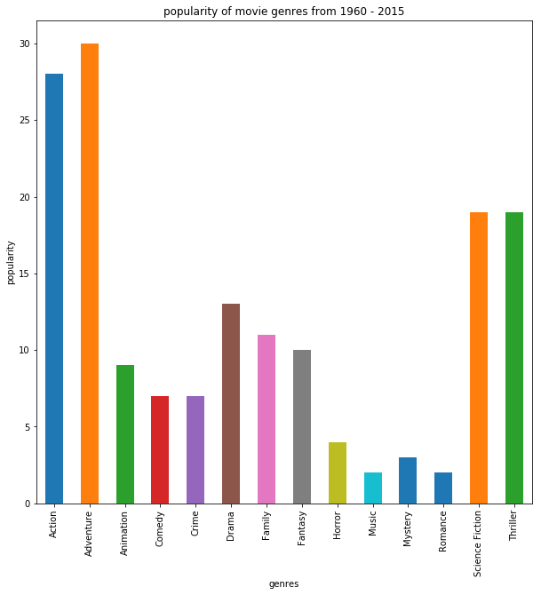

```python
#grouping data by genres

best_in_year.groupby('genres')['vote_count'].count().plot(kind='bar', figsize=(10,10));
plt.title('popularity of movie genres from 1960 - 2015')
plt.ylabel('popularity')
```

### Research Question 2 : What kind of properties are associated with movies that have high revenues?

```python
#importing library

import seaborn as sns
```

```python
df_sep_gen.drop('director', axis=1,inplace=True)
```

```python
# change budget, revenue, revenue_adj, buget_adj in million dollar

col_ch = ['budget', 'revenue', 'budget_adj', 'revenue_adj']

for col in col_ch:
    df_sep_gen[col] = df_sep_gen[col]/1000000

df_sep_gen.head(10)
```

|  | popularity | budget | revenue | runtime | genres | vote_count | vote_average | release_year | budget_adj | revenue_adj |
| --- | --- | --- | --- | --- | --- | --- | --- | --- | --- | --- |
| 0 | 4.566713 | 150.0 | 682.330139 | 131 | Action | 2349 | 7.1 | 2015 | 137.999939 | 627.743452 |
| 1 | 4.564549 | 68.0 | 215.863606 | 115 | Comedy | 1666 | 6.3 | 2015 | 62.559972 | 198.594430 |
| 2 | 2.814802 | 35.0 | 194.564672 | 121 | Comedy | 1255 | 7.1 | 2015 | 32.199986 | 178.999419 |
| 3 | 2.584264 | 20.0 | 36.606743 | 100 | Drama | 631 | 6.3 | 2015 | 18.399992 | 33.678189 |
| 4 | 2.557859 | 15.0 | 64.191523 | 120 | Drama | 867 | 7.3 | 2015 | 13.799994 | 59.056175 |
| 5 | 2.331567 | 35.0 | 137.935567 | 133 | Drama | 1171 | 7.3 | 2015 | 32.199986 | 126.900666 |
| 6 | 2.317670 | 35.0 | 140.795793 | 125 | Comedy | 849 | 6.1 | 2015 | 32.199986 | 129.532073 |
| 7 | 2.272044 | 0.0 | 0.045895 | 95 | Thriller | 81 | 5.5 | 2015 | 0.000000 | 0.042223 |
| 8 | 2.121884 | 35.0 | 48.623572 | 123 | Drama | 500 | 6.9 | 2015 | 32.199986 | 44.733667 |
| 9 | 2.096273 | 25.0 | 52.395996 | 100 | Comedy | 363 | 6.1 | 2015 | 22.999990 | 48.204295 |

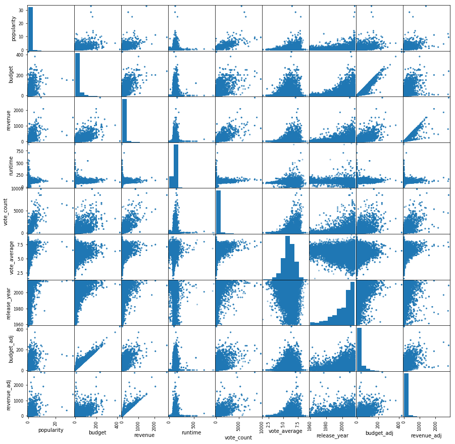

```python
#plotting correlation between all columns
pd.plotting.scatter_matrix(df_sep_gen, figsize=(15,15));
```

It is hard to find features that correlates with revenue_adj, but in a glance budget_adj, popularity, vote_count, and vote_average seems have correlation with it. More detail exploration is needed to ensure the correlation.

```
Text(0.5,0,'budget_adj (in million dollar)')
```

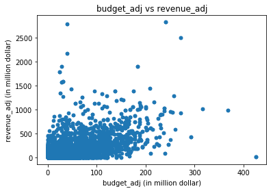

```python
df_sep_gen.plot(x='budget_adj', y='revenue_adj', kind='scatter');
plt.title('budget_adj vs revenue_adj')
plt.ylabel('revenue_adj (in million dollar)')
plt.xlabel('budget_adj (in million dollar)')
```

```
Text(0.5,0,'popularity')
```

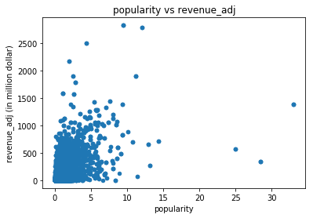

```python
df_sep_gen.plot(x='popularity', y='revenue_adj', kind='scatter');
plt.title('popularity vs revenue_adj')
plt.ylabel('revenue_adj (in million dollar)')
plt.xlabel('popularity')
```

```
Text(0.5,0,'vote_count')
```

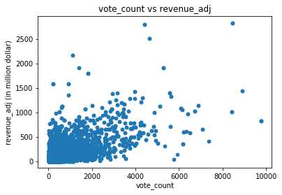

```python
df_sep_gen.plot(x='vote_count', y='revenue_adj', kind='scatter');
plt.title('vote_count vs revenue_adj')
plt.ylabel('revenue_adj (in million dollar)')
plt.xlabel('vote_count')
```

```
Text(0.5,0,'vote average')
```

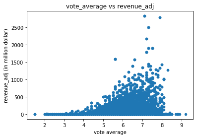

```python
df_sep_gen.plot(x='vote_average', y='revenue_adj', kind='scatter');
plt.title('vote_average vs revenue_adj')
plt.ylabel('revenue_adj (in million dollar)')
plt.xlabel('vote average')
```

After seeing in more detail, budget_adj,popularity and vote_count has positive correlation with revenue_adj. Vote_average seems have positive correlation with revenue_adj but after 7 in vote_average, most of revenue is going drop. Ensuring this hypothesis, we will see it in more detail by categorizing revenue into low and high revenue.

### In depth analysis with budget_adj

```python
# general statistic of revenue
df_sep_gen['revenue_adj'].describe()
```

```
count    26864.000000
mean        61.094461
std        161.765454
min          0.000000
25%          0.000000
50%          0.000000
75%         44.028789
max       2827.123750
Name: revenue_adj, dtype: float64
```

```python
# separating dataframe into low and high revenue by its mean

low_revenue = df_sep_gen[df_sep_gen['revenue_adj']<df_sep_gen['revenue_adj'].mean()]
high_revenue = df_sep_gen[df_sep_gen['revenue_adj']>=df_sep_gen['revenue_adj'].mean()]
```

```python
low_revenue.shape
```

```
(21035, 10)
```

```python
high_revenue.shape
```

```
(5829, 10)
```

```python
#budget_adj mean comparison in low and high revenue
print('budget_adj mean in low revenue : {}'.format(low_revenue['budget_adj'].mean()))
print('budget_adj mean in high revenue : {}'.format(high_revenue['budget_adj'].mean()))
```

[output not shown]

```python
low_revenue.revenue_adj.hist(bins=2, label='low revenue')
high_revenue.revenue_adj.hist(alpha=0.5,bins=5, label='high revenue')
plt.legend()
```

[output not shown]

## depth analysis with popularity

```python
low_revenue.popularity.describe()
```

```
count    21035.000000
mean         0.432291
std          0.418101
min          0.000188
25%          0.194002
50%          0.329831
75%          0.538043
max          8.411577
Name: popularity, dtype: float64
```

```python
high_revenue.popularity.describe()
```

```
count    5829.000000
mean        1.702888
std         1.961969
min         0.010335
25%         0.732485
50%         1.195330
75%         1.972826
max        32.985763
Name: popularity, dtype: float64
```

```python
#popularity mean comparison in low and high revenue
print('popularity mean in low revenue : {}'.format(low_revenue['popularity'].mean()))
print('popularity mean in high revenue : {}'.format(high_revenue['popularity'].mean()))
```

```
popularity mean in low revenue : 0.43229126570002374
popularity mean in high revenue : 1.7028883823983527
```

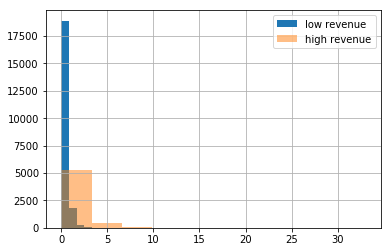

```python
low_revenue.popularity.hist( label='low revenue')
high_revenue.popularity.hist(alpha=0.5, label='high revenue')
plt.legend()
```

Popularity feature indicate low correlation with revenue_adj. From the popularity mean of low and high revenue,it can be seen that it have signigicant differencies. Unfortunately, from data spreading and long tail, high revenue histogram only moves slightly to the right from low revenue histogram. This condition can be cause by imbalance amount of data in low revenu and high revenue.

## depth analysis with vote count

```python
low_revenue.vote_count.describe()
```

```
count    21035.000000
mean        79.414737
std        168.489311
min         10.000000
25%         15.000000
50%         29.000000
75%         72.000000
max       5754.000000
Name: vote_count, dtype: float64
```

```python
high_revenue.vote_count.describe()
```

```
count    5829.000000
mean      869.195059
std      1136.166250
min        10.000000
25%       184.000000
50%       437.000000
75%      1074.000000
max      9767.000000
Name: vote_count, dtype: float64
```

```python
#vote count mean comparison in low and high revenue
print('vote count mean in low revenue : {}'.format(low_revenue['vote_count'].mean()))
print('vote count mean in high revenue : {}'.format(high_revenue['vote_count'].mean()))
```

```
vote count mean in low revenue : 79.41473734252436
vote count mean in high revenue : 869.1950591868246
```

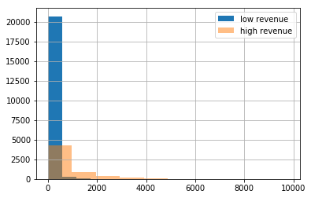

```python
low_revenue.vote_count.hist(bins=10, label='low revenue')
high_revenue.vote_count.hist(alpha=0.5, bins=10, label='high revenue')
plt.legend()
```

## depth analysis with vote average

```python
low_revenue.vote_average.describe()
```

```
count    21035.000000
mean         5.857048
std          0.933323
min          1.500000
25%          5.300000
50%          5.900000
75%          6.500000
max          9.200000
Name: vote_average, dtype: float64
```

```python
high_revenue.vote_average.describe()
```

```
count    5829.000000
mean        6.305576
std         0.725289
min         3.400000
25%         5.800000
50%         6.300000
75%         6.800000
max         8.300000
Name: vote_average, dtype: float64
```

```python
#vote average mean comparison in low and high revenue
print('vote average mean in low revenue : {}'.format(low_revenue['vote_average'].mean()))
print('vote average mean in high revenue : {}'.format(high_revenue['vote_average'].mean()))
```

```
vote average mean in low revenue : 5.857047777513668
vote average mean in high revenue : 6.305575570423743
```

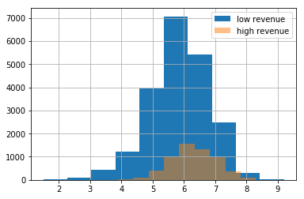

```python
low_revenue.vote_average.hist(bins=10, label='low revenue')
high_revenue.vote_average.hist(alpha=0.5, bins=10, label='high revenue')
plt.legend()
```

## Conclusions

Data exploration make me can answer 2 research questions. It needs re-grouping of data frame and basic statistic tools to process the data so that I can make sure what is the best answer for those questions.

Finding features that correlates with revenue become the last research question. It is quite hard to asses features that highly correlate with revenue. The process is started by using scatter matrix. Result from this step is several features that have tendency to correlate with revenue and those are budget_adj, popularity, vote_count and vote_average. For making sure the correlation between those features and revenue_adj, used general statistic assesment like mean and histogram. Gotten conclusion that budget_adj and vote_count have positive correlation with revenue_adj. Popularity has positive correlation too but it is weaker than 2 features before. And the last feature, vote_average, claimed having no correlation with revenue_adj.

## Submitting your Project

> Before you submit your project, you need to create a .html or .pdf version of this notebook in the workspace here. To do that, run the code cell below. If it worked correctly, you should get a return code of 0, and you should see the generated .html file in the workspace directory (click on the orange Jupyter icon in the upper left).

> Alternatively, you can download this report as .html via the **File** > **Download as** submenu, and then manually upload it into the workspace directory by clicking on the orange Jupyter icon in the upper left, then using the Upload button.

> Once you've done this, you can submit your project by clicking on the "Submit Project" button in the lower right here. This will create and submit a zip file with this .ipynb doc and the .html or .pdf version you created. Congratulations!

```python
from subprocess import call
call(['python', '-m', 'nbconvert', 'Investigate_a_Dataset.ipynb'])
```

```
0
```